# PACMOS-lungNEN-fuzzy-tutorial

# Introduction

PACMOS is an R package designed to project new query samples into a reference multi-omics latent space derived from MOFA models, enabling sample-level interpretation within an established biological context. It is particularly suited for translational and cancer multi-omics applications where robust comparison of new samples against established molecular reference cohorts is required.

This vignette demonstrates the PACMOS workflow using the LungNET dataset generated from lung neuroendocrine tumours from the LungNENomics cohort, based on the integrative multi-omics framework described at https://doi.org/10.1101/2025.07.18.25331556.

The reference datasets required by PACMOS are provided within the package under inst/extdata/lungNEN_references/. These reference objects consist of MOFA-compatible matrices where rows correspond to genes or molecular features and columns correspond to reference samples across multiple omics layers.

Query samples are expected as one or more CSV files in which the first column contains gene or feature identifiers, followed by one or more columns representing query samples. Query datasets should use feature identifiers compatible with the reference matrices and may contain one or several omics modalities corresponding to the reference MOFA views.

This vignette demonstrates how to:

0. Install PACMOS
1. Add query samples to MOFA reference inputs
2. Run MOFA2 retraining
3. Project query samples into the reference MOFA latent space
4. Infer archetype weights of query samples
5. Visualize query samples within Pareto archetype space

## Step 0: Installation

Before using PACMOS, make sure you have the required Python environment.

For Linux/macOS, open a terminal.

```bash
git clone https://github.com/IARCbioinfo/PACMOS.git
cd PACMOS
conda env create -f pacmos_env.yml
conda activate pacmos_env

# Linux/macOS users:
which python
```

For Windows, download the PACMOS repository as a ZIP file from https://github.com/IARCbioinfo/PACMOS. Extract the ZIP archive, then open the **Anaconda Prompt** and run:

```bash
cd <dir-to-PACMOS>\PACMOS-main

dir

conda env create -f pacmos_env.yml
conda activate pacmos_env

where python
```

These commands return the Python executable inside the `pacmos_env` Conda environment. The path will look similar to:

```
## Linux/macOS
/home/user/miniconda3/envs/pacmos_env/bin/python

## windows
C:/Users/YOUR_USERNAME/miniconda3/envs/pacmos_env/python.exe
```

```r
# install.packages("devtools")
devtools::install_github("IARCbioinfo/PACMOS", dependencies = TRUE)
```

```r
library(PACMOS)
```

Example data paths

```r
mofa_dir <- system.file("extdata/lungNEN_references", package = "PACMOS")
reference_LFs  <- system.file("extdata/lungNEN_references", "lungNEN_LFs.csv", package = "PACMOS")
query_csv <- system.file("extdata/test_data", "lungNEN_test_expr.csv", package = "PACMOS")


out_dir <- file.path('.', "lungNEN_output")
dir.create(out_dir, recursive = TRUE, showWarnings = FALSE)
out_dir
```

```
#> [1] "./lungNEN_output"
```

```r
python_path <- "/home/lipikal/miniconda3/envs/pacmos_env/bin/python"
                # replace with your local path
```

## Step 1: Add query samples to MOFA inputs

This function integrates one or more query samples into reference multi-omic MOFA input matrices using an incremental approach. For each query sample, it aligns gene identifiers with the reference matrices, inserts observed values into the corresponding data layer, and fills all other layers with NA to maintain a consistent structure across views.

The function creates a structured output directory where each query sample has its own folder, containing an inputs/ subdirectory with all .RData matrices required for downstream MOFA training.

```r
## -----------------------------------------------------------------------------
print('Starting Step 1')
```

```
#> [1] "Starting Step 1"
```

```r
PACMOS::s1_add_sample_to_mofa(
  query_matrix_path = query_csv,
  mofa_dir = mofa_dir,
  value_data_types = c('D_expr_MOFA'),
  outdir = out_dir,
  python_bin = python_path
)
```

```
#> - Pairing (query_matrix_path -> data_type):
#>   - [1] lungNEN_test_expr.csv -> D_expr_MOFA
#> - Processing file #1: lungNEN_test_expr.csv (2 sample(s)) against data_type 'D_expr_MOFA'
#>
#> ==============================
#> Processing sample:  SRR10720230
#> ==============================
#>    |_ Saved: D_alt_MOFA_SRR10720230.RData
#>    |_ Saved: D_cnv_MOFA_SRR10720230.RData
#> --[D_expr_MOFA | SRR10720230] gene order OK (5000/5000 matched)
#>    |_ Saved: D_expr_MOFA_SRR10720230.RData
#>    |_ Saved: D_met_MOFA_SRR10720230.RData
#>
#>  Completed sample: SRR10720230
#>
#>
#> ==============================
#> Processing sample:  SRR10720231
#> ==============================
#>    |_ Saved: D_alt_MOFA_SRR10720231.RData
#>    |_ Saved: D_cnv_MOFA_SRR10720231.RData
#> --[D_expr_MOFA | SRR10720231] gene order OK (5000/5000 matched)
#>    |_ Saved: D_expr_MOFA_SRR10720231.RData
#>    |_ Saved: D_met_MOFA_SRR10720231.RData
#>
#>  Completed sample: SRR10720231
```

```r
cat("Outputs are saved in:", out_dir, "\n")
```

```
#> Outputs are saved in: ./lungNEN_output
```

## Step 2: Train MOFA models

This function trains MOFA models for each query sample using the prepared input matrices. It loads the multi-omic inputs generated in Step 1, configures the model according to the specified views and data types (including binary layers), and runs MOFA.

Each query sample is processed independently, producing a trained MOFA model.

```r
print('Starting Step 2')
```

```
#> [1] "Starting Step 2"
```

```r
PACMOS::s2_run_mofa(
  models_dir      = out_dir,
  matrices_subdir = "inputs",
  num_factors = 10,
  convergence_mode = "slow",
  maxiter = 10000,
  use_basilisk = FALSE,
  skip_existing = TRUE,
  python_bin      = python_path,
  views_map = c(
    RNA     = "D_expr_MOFA",
    Meth    = "D_met_MOFA",
    CNV     = "D_cnv_MOFA",
    Alt     = "D_alt_MOFA"
  ),
  binary_views = "Alt"
)
```

[output not shown]

[output cut: 1983 more lines]

```
#> Converged!
#>
#>
#>
#> #######################
#> ## Training finished ##
#> #######################
#>
#>
#> Saving model in ./lungNEN_output/SRR10720231/inputs/MOFA-SRR10720231.hdf5...
#> - Saved: ./lungNEN_output/SRR10720231/inputs/MOFA-SRR10720231.hdf5
#>
#> - Run summary -
#>   SRR10720230: OK
#>   SRR10720231: OK
```

```r
cat("Outputs are saved in:", out_dir, "\n")
```

```
#> Outputs are saved in: ./lungNEN_output
```

## Step 3: Visualize query samples

This function projects query samples into the reference/retrained latent factor space and generates quality control visualizations. It compares the learned latent factors of retrained models with reference axes, computes correlations, and produces diagnostic plots to assess how well the query samples align with known biological structure.

The outputs are saved as PDF files for each sample in the `outputs` directory inside each query sample folder.

```r
print('Starting Step 3')
```

```
#> [1] "Starting Step 3"
```

```r
sample_dirs <- list.dirs(out_dir, recursive = FALSE, full.names = TRUE)
sample_dirs <- sample_dirs[dir.exists(file.path(sample_dirs, "inputs"))]
sample_ids <- basename(sample_dirs)

s3_results <- list()

for (id in sample_ids) {
  s3_results[[id]] <- PACMOS::s3_plot_query_samples_mofa(
    models_dir      = out_dir,
    matrices_subdir = "inputs",
    query_sample    = id,
    reference_LFs   = reference_LFs,
    reference_axes  = c(
      "Factor1",
      "Factor2",
      "Factor5"
    ),
    group = "group1",
    python_bin = python_path
  )
}
```

```
#>
#> =============================================
#>   [1 / 2]  SRR10720230
#> =============================================
#>   Training samples : 319
#>   Query sample      : SRR10720230
#>   Writing outputs to: ./lungNEN_output/SRR10720230/outputs
#>   [DONE] SRR10720230
#>
#> =============================================
#>
#>   Outputs in        : ./lungNEN_output/SRR10720230/outputs
#>
#> =============================================
#>
#>
#>
#> =============================================
#>
#>   [2 / 2]  SRR10720231
#>
#> =============================================
#>
#>   Training samples : 319
#>
#>   Query sample      : SRR10720231
#>
#>   Writing outputs to: ./lungNEN_output/SRR10720231/outputs
#>
#>   [DONE] SRR10720231
#>
#> =============================================
#>
#>   Outputs in        : ./lungNEN_output/SRR10720231/outputs
#>
#> =============================================
```

```r
cat("Outputs are saved in:", out_dir, "\n")
```

```
#> Outputs are saved in: ./lungNEN_output
```

### Interpreting Step 3 quality control

Step 3 checks whether the latent factors learned after adding the query sample can be aligned back to the original reference MOFA space.

The QC PDF contains three main diagnostics (Good alignment is indicated by high absolute correlation, a clear diagonal trend in the scatter plot, and relatively low RMSE):

1. **Factor assignment summary**: shows which retrained MOFA factor was matched to each reference latent factor.
2. **Correlation heatmap**: The heatmap shows correlations between retrained MOFA factors and reference latent factors. Rows are retrained MOFA factors and columns are reference axes. The black boundary marks the selected factor for each reference axis.

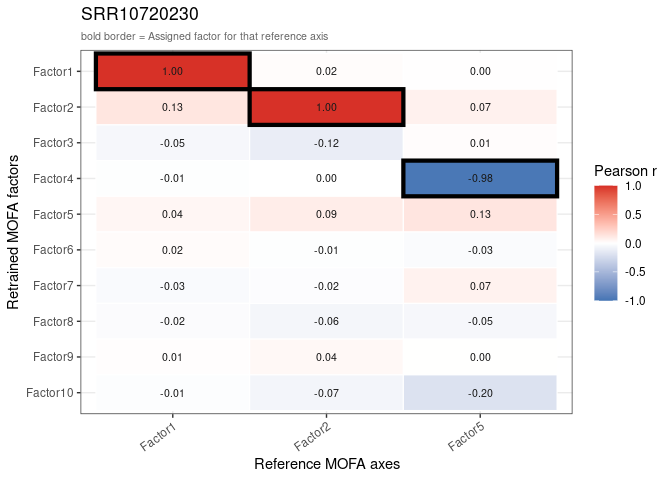

```r
sample_to_show <- sample_ids[1]

s3_results[[sample_to_show]]$plots$alignment_heatmap
```

3. **Scatter plots**: The scatter plot compares reference LF values with aligned retrained LF values. A strong diagonal trend and high correlation indicate successful alignment.

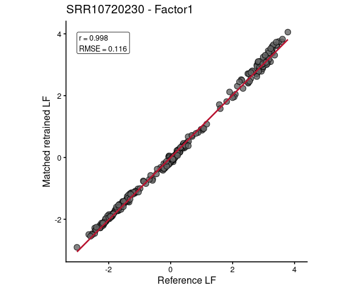

```r
s3_results[[sample_to_show]]$plots$scatter_by_axis$Factor1
```

The projection plot shows the query sample highlighted in red within the reference latent factor space (grey points).

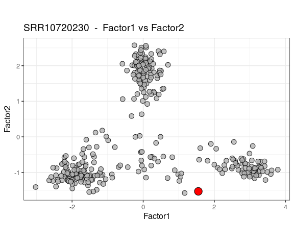

```r
s3_results[[sample_to_show]]$plots$projection_pairs[[1]]
```

## Step 4: Infer archetype weights

This function estimates the contribution of predefined biological archetypes to each query sample using a fuzzy weighting approach. Based on the latent factor coordinates obtained from MOFA, it calculates the degree to which each sample belongs to each archetype.

The result is saved as a csv file in the `outputs` directory.

```r
print('Starting Step 4')
```

```
#> [1] "Starting Step 4"
```

```r
archetype_coords <- data.frame(
  Archetype = c("sc-enriched", "Ca A1", "Ca B", "Ca A2"),
  Factor1   = c( 0.115975, -2.808502,  3.587424, -0.009624),
  Factor2   = c(-0.663702, -1.362303, -0.980481,  2.544914),
  Factor5   = c(-5.090584,  1.194101,  0.919848,  0.810954),
  stringsAsFactors = FALSE
)

PACMOS::infer_fuzzy_weights(
  models_dir      = out_dir,
  coord           = archetype_coords,
  n_archetypes    = 4,
  input_type      = "stable"
)
```

```
#> Archetypes (4): sc-enriched, Ca A1, Ca B, Ca A2
#> Found 2 sample dir(s).
#>
#> =============================================
#>   [1 / 2]  SRR10720230
#> =============================================
#>   Saved (query only) : SRR10720230_archetype_weights.csv
#>   Saved (all samples): SRR10720230_archetype_weights_all_samples.csv
#>
#> =============================================
#>   [2 / 2]  SRR10720231
#> =============================================
#>   Saved (query only) : SRR10720231_archetype_weights.csv
#>   Saved (all samples): SRR10720231_archetype_weights_all_samples.csv
#>
#> =============================================
#>   Processed  : 2 samples
#>   Aggregated : ./lungNEN_output/archetype_weights/_archetype_weights.csv
#> =============================================
```

```r
cat("Outputs are saved in:", out_dir, "\n")
```

```
#> Outputs are saved in: ./lungNEN_output
```

## Step 5: Plot results

This function visualizes the archetype composition of query samples based on the inferred fuzzy weights.

```r
print('Starting Step 5')
```

```
#> [1] "Starting Step 5"
```

```r
fuzzy_results <- PACMOS::plot_fuzzy_query_sample(
  models_dir      = out_dir
)
```

```
#> Found 2 sample folder(s).
#>
#> =============================================
#>   SRR10720230
#> =============================================
#>   Processing: SRR10720230_archetype_weights_all_samples.csv
#>   Saved: SRR10720230_archetype_projection.pdf
#>
#> =============================================
#>   SRR10720231
#> =============================================
#>   Processing: SRR10720231_archetype_weights_all_samples.csv
#>   Saved: SRR10720231_archetype_projection.pdf
#>
#> =============================================
#>   Done. 2 sample(s) processed.
#> =============================================
```

```r
cat("Outputs are saved in:", out_dir, "\n")
```

```
#> Outputs are saved in: ./lungNEN_output
```

```r
sample_to_show <- sample_ids[1]

knitr::include_graphics(
  fuzzy_results$samples[[sample_to_show]]$files$projection_pdf
)
```

[figure not shown]